# Modelling dose-reponse data in R

# Introduction

In this session, we will apply dose-response models to four different topics:

1. Simple dose-response model
2. Comparison of dose-response models
3. Species sensitivity distributions
4. Multiple dose-response models

**Acknowledgement** My R code is loosely based on Ritz et al. (2021), an R Markdown document related to a talk by Christian Ritz 2021 that he kindly shared and [this online course](https://uncsrp.github.io/Data-Analysis-Training-Modules/dose-response-modeling.html#comparing-curve-fits).

# Simple dose-response model

We use data from an experiment where the herbicidal effect of ferulic acid on the root growth of ryegrass was examined at 7 concentration levels, including a control. The dataset contains only two variables: *rootl* and *conc*.

```r
library(drc)
# R package that contains the data
data(ryegrass)
head(ryegrass)
```

|  | rootl | conc |
| --- | --- | --- |
| 1 | 7.580000 | 0 |
| 2 | 8.000000 | 0 |
| 3 | 8.328571 | 0 |
| 4 | 7.250000 | 0 |
| 5 | 7.375000 | 0 |
| 6 | 7.962500 | 0 |

Now we fit the dose-response model using a 4-parameter log-logistic model.

```r
ryegrass.LL.4 <- drm(rootl ~ conc, data = ryegrass, fct = LL.4())
```

The syntax for fitting the model is the same as for other R functions such as `lm()`. The argument `fct` specifies the type of dose response model, where *LL* stands for the Log-Logistic model. `LL.4()` is the log-logistic model with 4 parameters. `LL.2()` would be the version with two parameters. **Which parameters would this include, and why is this model not suitable for our ryegrass data?**

As with other models in R, we can use the `summary()` function to obtain parameter estimates along with associated *p*-values from *t*-tests. The parameter *e* gives the EC50.

```r
summary(ryegrass.LL.4)
```

```
Model fitted: Log-logistic (ED50 as parameter) (4 parms)

Parameter estimates:

              Estimate Std. Error t-value   p-value
b:(Intercept)  2.98222    0.46506  6.4125 2.960e-06 ***
c:(Intercept)  0.48141    0.21219  2.2688   0.03451 *
d:(Intercept)  7.79296    0.18857 41.3272 < 2.2e-16 ***
e:(Intercept)  3.05795    0.18573 16.4644 4.268e-13 ***
---
Signif. codes:  0 ‘***’ 0.001 ‘**’ 0.01 ‘*’ 0.05 ‘.’ 0.1 ‘ ’ 1

Residual standard error:

 0.5196256 (20 degrees of freedom)
```

We can also directly extract EC-values using the `ED()` function for desired effect levels. Here, we extract the 10th, 50th (i.e. EC50) and 90th percentiles.

```r
ED(ryegrass.LL.4, c(10, 50, 90))
```

```
Estimated effective doses

       Estimate Std. Error
e:1:10  1.46371    0.18677
e:1:50  3.05795    0.18573
e:1:90  6.38864    0.84510
```

We plot the model, again using the familiar `plot()` function in R.

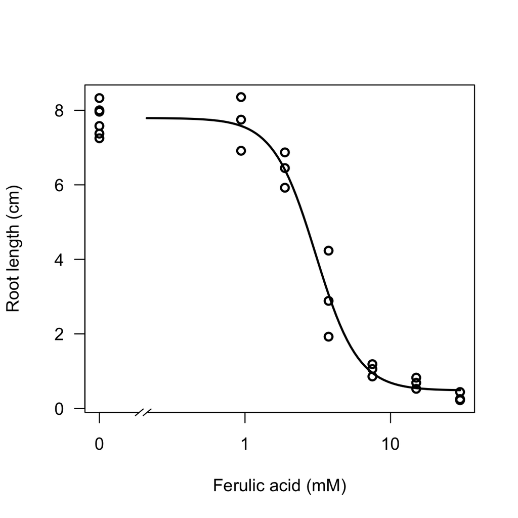

```r
plot(ryegrass.LL.4, broken = TRUE, type = "all",
xlab = "Ferulic acid (mM)", ylab = "Root length (cm)", lwd = 2)
```

The fitted curve matches the observations quite well.

However, let us now check the model assumptions. We first evaluate model fit using the Q-Q plot.

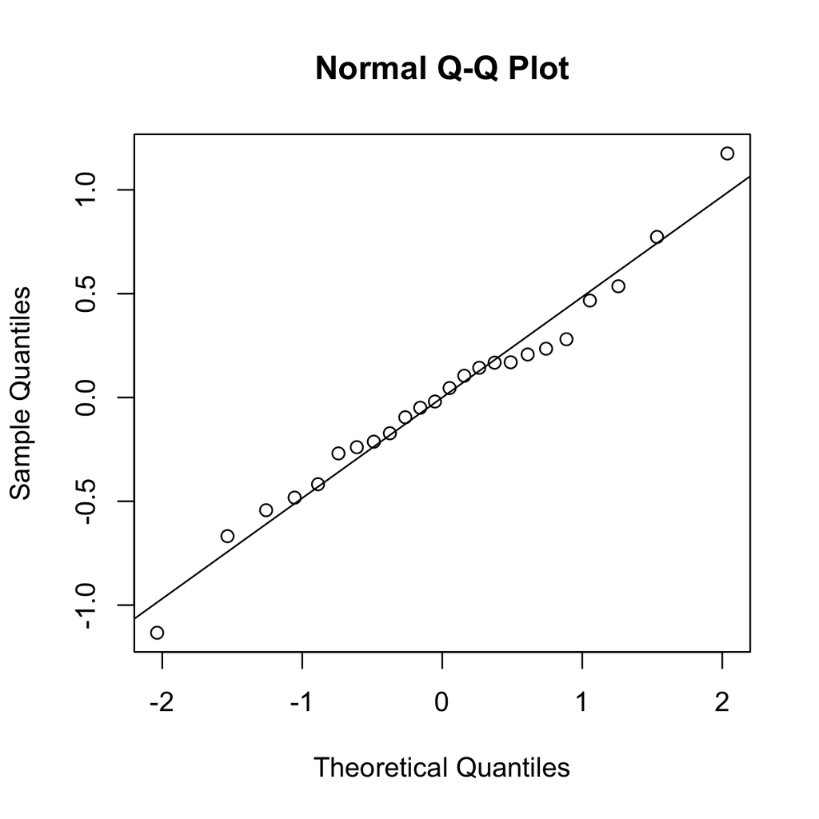

```r
qqnorm(residuals(ryegrass.LL.4))
abline(a = 0, b = sd(residuals(ryegrass.LL.4)))
```

The Q-Q plot indicates that the normality assumption for the errors appears reasonable, as the ranked (raw) residuals approximately follow the expected values under a normal distribution.

Next, we check the assumption of variance homogeneity using a residuals vs. fitted values plot.

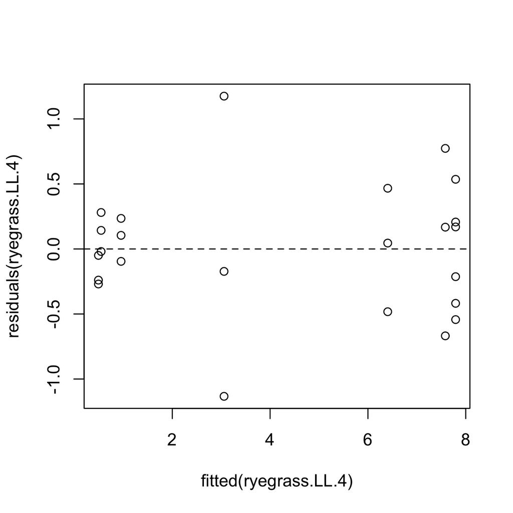

```r
plot(fitted(ryegrass.LL.4), residuals(ryegrass.LL.4))
abline(h = 0, lty = 2)
```

The residuals vs. fitted values plot indicates that the chosen model function provides an appropriate description of the dose-response data. The residuals are randomly scattered around the reference line, which is the x-axis, given that the residuals should be centered around 0. Moreover, the spread of points appears consistent across the range of fitted values, which represents the range of predicted responses. This supports that the model assumption of variance homogeneity is met.

Finally, we produce a plot using the *ggplot2* package instead of base graphics. I provide the code below, but introducing this plotting system is beyond the scope of this course. However, the beginning of the code also shows how to create confidence intervals through prediction using the fitted model. **Inspect the *newdata* object, what are these values?**

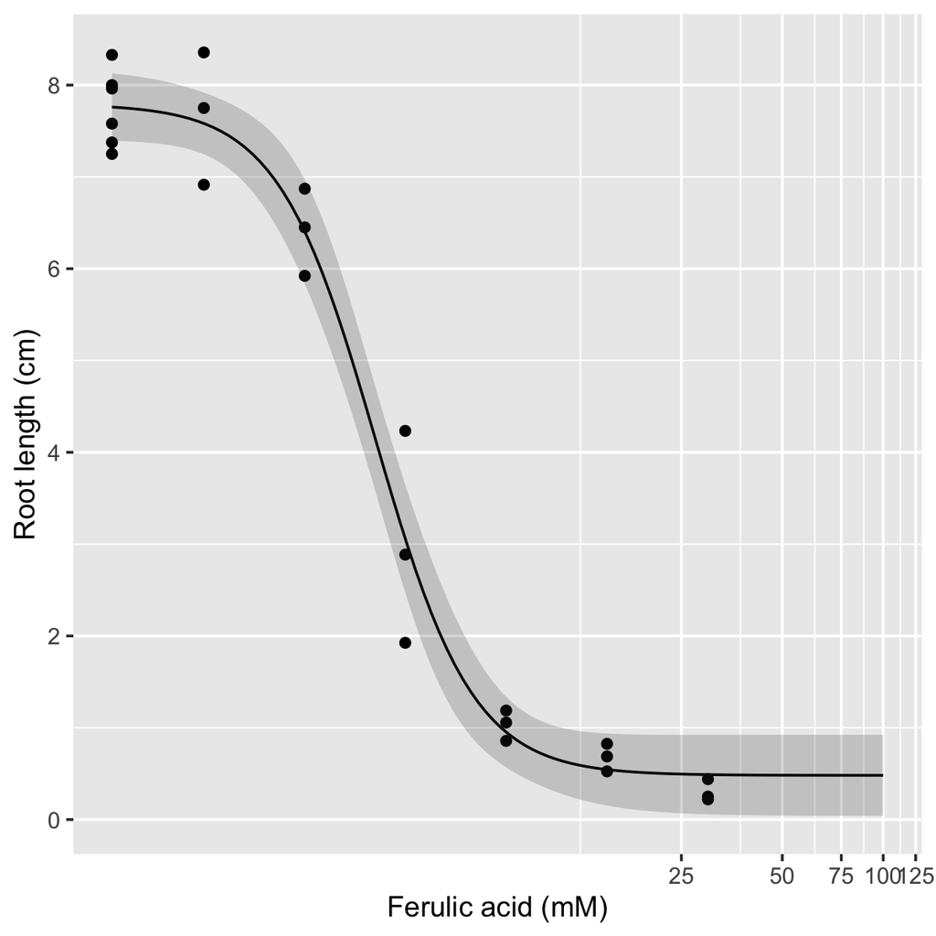

```r
library(ggplot2)
newdata <- expand.grid(conc = exp(seq(log(0.5), log(100),
length = 100)))
# we wrap the predict function inside a function that suppresses warnings because these are non-informative in our case and would only detract in this notebook. However, the warnings would not affect functionality of the code.
suppressWarnings(pm <- predict(ryegrass.LL.4, newdata = newdata,
interval = "confidence"))
newdata$p <- pm[ , 1]
newdata$pmin <- pm[ , 2]
newdata$pmax <- pm[ , 3]
# given that the log for 0 is not defined, we set the lowest value to 0.5, but create a new concentration vector. This is good practice, never overwrite the raw data!
ryegrass$conc0 <- ryegrass$conc
ryegrass$conc0[ryegrass$conc0 == 0] <- 0.5

ggplot(ryegrass, aes(x = conc0, y = rootl)) +
geom_point() +
geom_line(data = newdata, aes(x = conc, y=p)) +
geom_ribbon(data = newdata,
aes(x = conc, y = p, ymin = pmin, ymax = pmax),
alpha = 0.2) +
coord_transform(x = "log") +
xlab("Ferulic acid (mM)") + ylab("Root length (cm)")
```

**Now it is up to you!**

1. Load the *secalonic* dataset using the `data()`. Subsequently, inspect the data using the function `?secalonic`.
2. Fit a 4-parameter log-logistic model to the data and evaluate the model assumptions.
3. Extract the EC<sub>10</sub> and EC<sub>20</sub> from the model.

# Comparison of dose-response models

Let us now fit different types of dose-response models to the data and compare their fit. We have already fitted a log-logistic model and we will now fit a range of other models: Weibull type 1 model with four parameters (*W1.4*), log-normal model with four parameter (*LN.4*) and a Brain-Cousens model for hormesis with 5 parameters (*BC.5*), though the data do not suggest the presence of hormesis (see Calabrese (2013) for an overview on the concept of hormesis). For an overview of model types and their typical applications see the Appendix B of Ritz et al. (2021).

```r
# fit Weibull type 1 model
ryegrass.W14 <- drm(rootl ~ conc, data = ryegrass, fct = W1.4())
# fit log-normal model
ryegrass.LN4 <- drm(rootl ~ conc, data = ryegrass, fct = LN.4())
# fit Brain-Cousens model
ryegrass.BC5 <- drm(rootl ~ conc, data = ryegrass, fct = BC.5())
```

We plot all models in one figure. This can be done conveniently with the `add = TRUE` argument; the other arguments set the color, line type (`lty`) and line width (`lwd`).

```r
# Generating the plot
plot(ryegrass.LL.4, broken = TRUE, type="all")
# Can add the next models on top of current plot with different line types and weights
plot(ryegrass.W14, add = TRUE, col = "red", lty = 4, lwd = 1.5, broken = TRUE, type = "none")
```

```r
plot(ryegrass.LN4, add = TRUE, col = "blue", lty = 2, lwd = 1.5, broken = TRUE, type = "none")
plot(ryegrass.BC5, add = TRUE, col = "darkgreen", lty = 6, lwd = 1.5, broken = TRUE, type = "none")
```

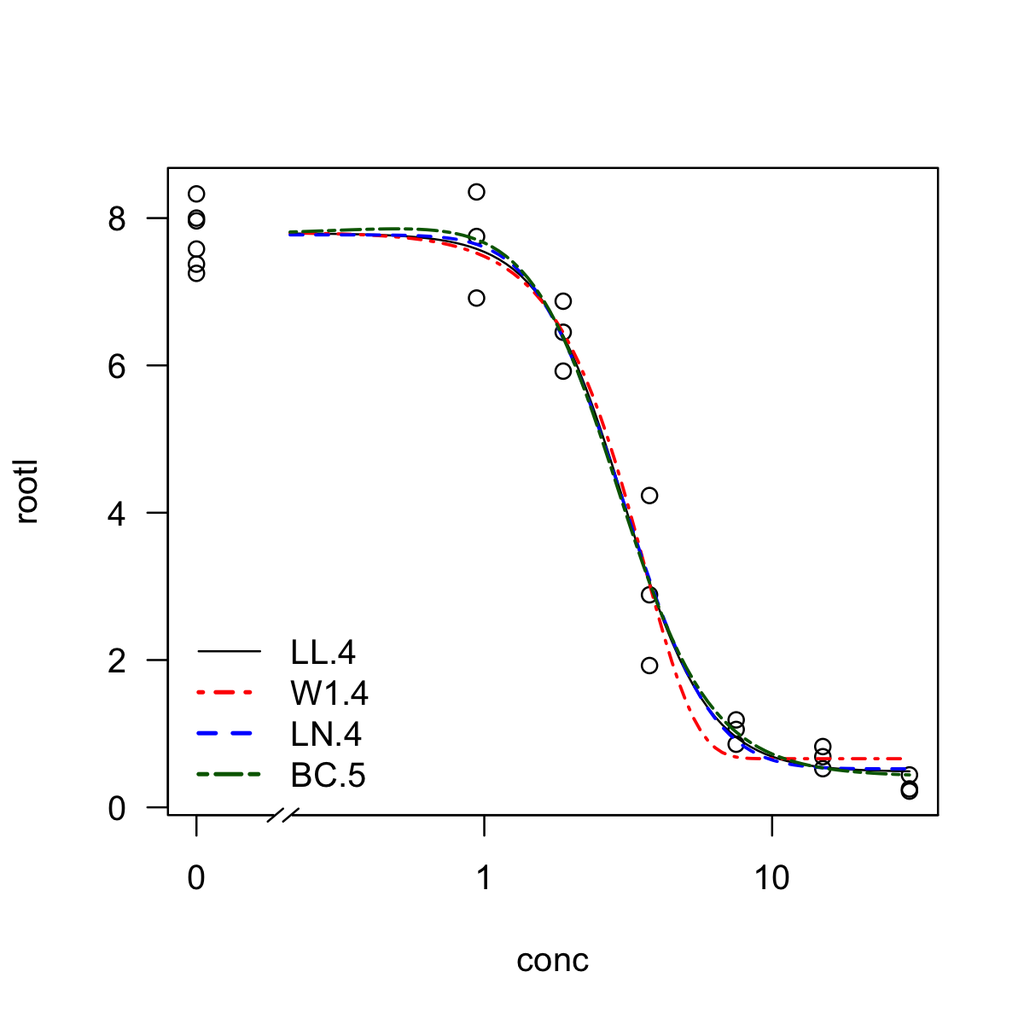

```r
legend("bottomleft", legend = c("LL.4", "W1.4", "LN.4", "BC.5"),
lty = c(1, 4, 2, 6), lwd = c(1, 2, 2, 2), col = c("black", "red", "blue", "darkgreen"), bty = "n")
```

The lines look very similar, except for Weibull type 1 model. Indeed, the log-normal and log-logistic model typically produce very similar results. The Brain-Cousens model has an extra parameter that enables it to capture potential hormesis, which is not required here. **Which model would you expect to have the highest AIC?**

We calculate the AICs for the different models.

```r
AIC(ryegrass.LL.4)
```

```
[1] 42.31029
```

```r
AIC(ryegrass.W14)
```

```
[1] 44.93439
```

```r
AIC(ryegrass.LN4)
```

```
[1] 42.58429
```

```r
AIC(ryegrass.BC5)
```

```
[1] 43.90926
```

**Now it is up to you!**

1. Load and inspect the *lettuce* dataset.
2. Fit multiple types of models to the data. You are free to choose some models, but make sure to also fit the two Brain-Cousens models (*BC.4* and *BC.5*). Compare the models and also evaluate model assumptions for the Brain-Cousens and other models.

# Species sensitivity distributions

The estimation of species sensitivity distributions (SSD) can also be considered as a special case of a dose-response analysis. While SSDs only fit a single type of dose-response model to the data, the result is visualized by means of a dose-response curve.

We use the *endosulfan* dataset, which consists of acute toxicity data in µg/L of a range of organism groups (i.e. arthropods, fish, amphibians). Note that generally it is more meaningful to fit SSDs to single organism groups, which is why we limit the data to non-Australian arthropods.

```r
library(fitdistrplus) # to retrieve the data
data("endosulfan")
head(endosulfan)
```

|  | ATV | Australian | group | taxa |
| --- | --- | --- | --- | --- |
| 1 | 0.6 | yes | Arthropods | Atalophlebia australis |
| 2 | 2.8 | yes | Arthropods | Caridinides sp. |
| 3 | 182.2 | yes | Arthropods | Ceriodaphnia dubia |
| 4 | 0.8 | yes | Arthropods | Cheumatopsyche |
| 5 | 478.0 | yes | Arthropods | Daphnia carinata |
| 6 | 1.1 | yes | Arthropods | Jappa kutera |

```r
endosulfan.art <- subset(endosulfan, group == "Arthropods" & Australian == "no")
```

We use the endosulfan data and fit an SSD. Several distributions are commonly used, some of which are identical to those used in the context of dose-response modeling using the *drc* package. For an overview and details of the distributions [see here](https://bcgov.github.io/ssdtools/articles/B_distributions.html). We start by fitting a log-normal model using the `ssd_fit_dists()` function. This model frequently provides an acceptable fit (Iwasaki & Yanagihara 2025). The argument `left` specifies the concentration vector, if it carries the name “Conc”, no specification is required. The `right` argument is used for censored data.

[figure not shown]

The fit looks reasonably good, but towards the extremes, the observations deviate a bit. This would be irrelevant if the focus is on the center of the distribution (e.g. HC<sub>50</sub>), but can be important if we focus on the margins of the distribution (e.g. HC<sub>5</sub>).

For SSDs we can also check the normality assumption with a Q-Q plot to spot deviations. We need a few lines of code and use the base R function `qqplot`.

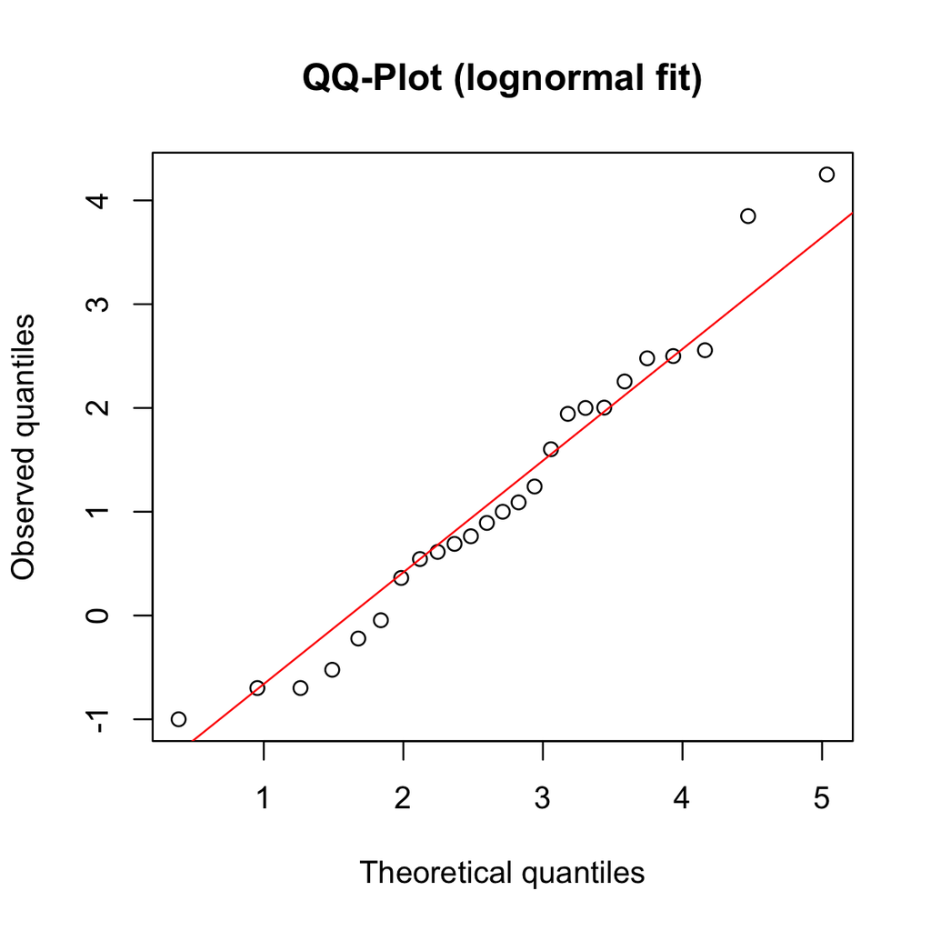

```r
# First we extract and sort the concentrations
Conc <- sort(endosulfan.art$ATV)
# Extract estimated parameters
params <- ssd_ln$lnorm$pars
# Assign mean and standard deviation to new object
# But need to convert to object type numeric
mlog <- as.numeric(params["meanlog"])
sdlog <- as.numeric(params["log_sdlog"])
# Now we determine the theoretical log-normal distribution
# Note that you would need to adjust this, if you fitted a different distribution
q_dist <- qnorm(ppoints(length(Conc)), mean = mlog, sd = sdlog)

# Generate Q-Q plot
qqplot(q_dist, log10(Conc), xlab = "Theoretical quantiles", ylab = "Observed quantiles",
  main = "QQ-Plot (lognormal fit)")
# We provide the ordinates for probability plotting with ppoints, the center of the distribution and the variability of the distribution. Note that once we know the center and the variability along with the sample size, we can specify the exact values of a theoretical distribution.
qqline(log10(Conc), distribution = function(p) qnorm(p, mean = mlog, sd = sdlog), col = "red")
```

In the Q-Q plot we can more clearly spot the deviations towards the upper end of the distribution. This may not be too dramatic if we determine the HC<sub>5</sub> from the lower end. Let us extract a Hazard Concentration (HC) now using the `ssd_hc()` function where the argument `proportion` determines the percentage of species affected by the HC.

```r
ssd_hc(ssd_ln, proportion = 0.05)
```

| dist | proportion | est | se | lcl | ucl | wt | level | est_method | ci_method | boot_method | nboot | pboot | dists | samples |
| --- | --- | --- | --- | --- | --- | --- | --- | --- | --- | --- | --- | --- | --- | --- |
| lnorm | 0.05 | 0.09222015 | NA | NA | NA | 1 | 0.95 | cdf | percentile | parametric | 0 | 1 |  |  |

```r
# we can also generate bootstrapped confidence intervals for this proportion
ssd_hc(ssd_ln, proportion = 0.05, ci = TRUE)
```

| dist | proportion | est | se | lcl | ucl | wt | level | est_method | ci_method | boot_method | nboot | pboot | dists | samples |
| --- | --- | --- | --- | --- | --- | --- | --- | --- | --- | --- | --- | --- | --- | --- |
| lnorm | 0.05 | 0.09222015 | 0.175898 | 0.0161613 | 0.5921117 | 1 | 0.95 | cdf | percentile | parametric | 1000 | 1 |  |  |

A nice feature of the `ssd_fit_dists()` function is that we can fit multiple distributions simultaneously. Let us fit multiple distributions and compare their fit, again using the AIC corrected for small sample size (i.e. corrected AIC (AIC<sub>c</sub>)).

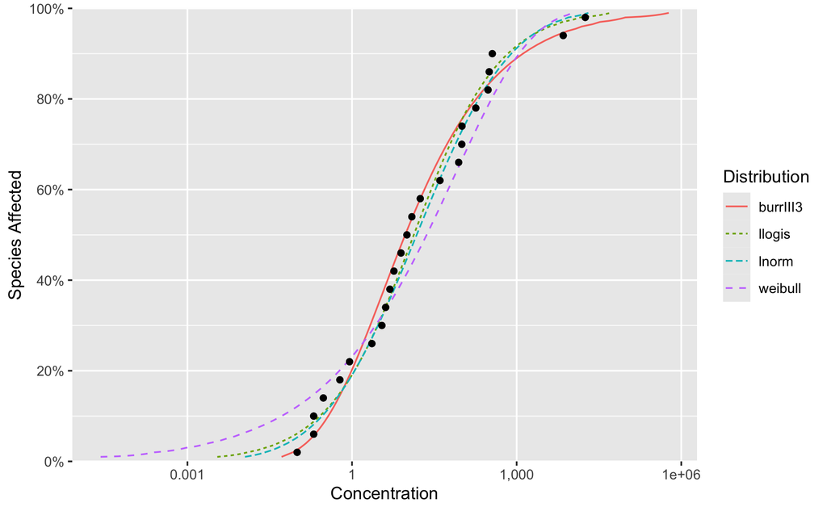

```r
ssd_fitdists <- ssd_fit_dists(data = endosulfan.art, left = "ATV", dists = c("lnorm", "burrIII3", "weibull", "llogis"))
ssd_plot_cdf(ssd_fitdists)
```

Visually, the Burr type III distribution provides the best fit to the data. Let us check with the AIC<sub>c</sub>.

```r
ssd_gof(ssd_fitdists, wt = TRUE)
```

| dist | npars | nobs | log_lik | aic | aicc | delta | wt | bic | ad | ks | cvm | at_bound | computable |
| --- | --- | --- | --- | --- | --- | --- | --- | --- | --- | --- | --- | --- | --- |
| lnorm | 2 | 25 | -131.5439 | 267.0878 | 267.6332 | 0.000 | 0.491 | 269.5255 | 0.2637043 | 0.08605632 | 0.03338895 | FALSE | TRUE |
| burrIII3 | 3 | 25 | -131.3133 | 268.6266 | 269.7694 | 2.136 | 0.169 | 272.2832 | 0.2777471 | 0.10408829 | 0.03956652 | TRUE | TRUE |
| weibull | 2 | 25 | -134.5209 | 273.0418 | 273.5872 | 5.954 | 0.025 | 275.4795 | 0.7105516 | 0.12834280 | 0.09459689 | FALSE | TRUE |
| llogis | 2 | 25 | -131.9873 | 267.9745 | 268.5200 | 0.887 | 0.315 | 270.4123 | 0.2556647 | 0.10046281 | 0.03328406 | FALSE | TRUE |

Finally, we compute the HC<sub>5</sub> with confidence intervals for the different distributions. For multiple distributions, we need to set the argument `average = FALSE` , which controls whether model averaging is conducted.

```r
hc_table <- ssd_hc(ssd_fitdists, proportion = 0.05, average = FALSE, ci = TRUE)
print(hc_table)
```

```
# A tibble: 4 × 15
  dist     proportion     est     se      lcl   ucl     wt level est_method ci_method  boot_method nboot pboot dists  samples
  <chr>         <dbl>   <dbl>  <dbl>    <dbl> <dbl>  <dbl> <dbl> <chr>      <chr>      <chr>       <dbl> <dbl> <list> <list>
1 lnorm          0.05 0.0922  0.202  0.0174   0.689 0.491   0.95 cdf        percentile parametric   1000     1 <chr>  <dbl>
2 burrIII3       0.05 0.177   0.175  0.0492   0.723 0.169   0.95 cdf        percentile parametric   1000     1 <chr>  <dbl>
3 weibull        0.05 0.00508 0.0603 0.000168 0.159 0.0250  0.95 cdf        percentile parametric   1000     1 <chr>  <dbl>
4 llogis         0.05 0.0678  0.172  0.00859  0.528 0.315   0.95 cdf        percentile parametric   1000     1 <chr>  <dbl>
```

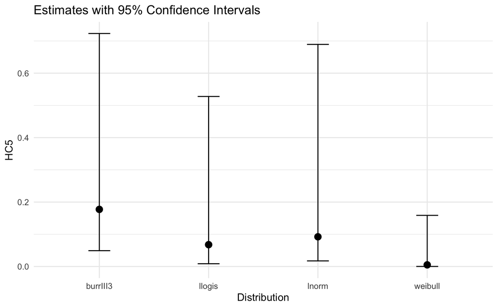

```r
# let us also plot the estimates with the confidence intervals.
library(ggplot2)
ggplot(hc_table, aes(x = dist, y = est)) +
  geom_point(size = 3) +  # Plot estimates
  geom_errorbar(aes(ymin = lcl, ymax = ucl), width = 0.2) +  # Confidence intervals
  labs(
    x = "Distribution",
    y = "HC5",
    title = "Estimates with 95% Confidence Intervals"
  ) +
  theme_minimal()
```

```r
NA
NA
```

**Now it is up to you!**

Fit an SSD for fish species in the endosulfan dataset and determine the range of HC<sub>5</sub> for several freely chosen distributions.